Econometrics and Statistics (520K)

# Econometric Methods in Business and Economics

Practical Class (Winter 24/25)

by Domenic Franjic

# Exercise Sheet No 10

Regression Analysis with a Binary Dependent Variable

## Set-Up

1) Create your (working) directory

Create a new folder on your computer in which you can save all necessary files, i.e., the data set, the R *script* with the implementation of your analysis and the R *helper function script* with some helper functions provided by us.

This folder, i.e., the path or directory of this folder, will be your so-called working directory.

2) Download the data set

Download the data set `HMDA_data.txt` from ILIAS directly or by using the link below:

[Download `HMDA_data.txt`](https://ilias.uni-hohenheim.de/goto.php?target=file_1548424_download&client_id=UHOH)

Save the data set into a (working) directory of your choice.

3) Prepare *script*

Open a new R *script* and save it into into your (working) directory.

Run the following code chunk to prepare your R *script*, i.e., to clear the work space and set your working directory.

```r
# Clear workspace
rm(list = ls(all = TRUE))
# Set working directory
setwd(".../set/your/working/directory/...")
```

4) Install/load *packages* and download/save/include *helper function script*

Step 1) Install all relevant R *packages* and download and save the R *script* `r_helper_functions.R` from ILIAS by running the following code chunk.

```r
# Download R-helper functions
source("https://ilias.uni-hohenheim.de/data/UHOH/lm_data/lm_1856939/MA_EconometricMethods_WiSe2324_PracticalClass/r-scripts/prepare_r_packages_and_helper_functions.R")
```

*Note*, the required R *packages* are `"moments"`, `"sandwich"`, `"lmtest"`, `"lmtest"`, `"car"`, `"plm"`, `"ivreg"`, `"dynlm"`, `"forecast"`, `"urca"`.

Step 2) Include the R *script* `r_helper_functions.R` into your R *script* by running the following code chunk.

```r
# Include R-helper functions
source("r_helper_functions.R")
```

*Note*, more information on the helper functions can be found here.

## Task 1

Access to Mortgages

We return to the analysis of the access to mortgages from the lecture. For this we use the data set `HMDA_data.txt` containing data compiled under the Home Mortgage Disclosure Act (HMDA) about mortgage applications filed in the Boston, Massachusetts, area in 1990 with the variables described below.

Variables

| Variable | Description |
| --- | --- |
| $deny$ | Factor. Was the mortgage denied? |
| $pirat$ | Payments to income ratio. |
| $black$ | Factor. Is the individual African-American? |

### Task a)

Load the data set into your favorite statistics software. Transform the variable $deny$ into a binary variable ($1$ is deny and $0$ otherwise) and the discuss its descriptive statistics. Draw as scatter plot of $deny$ and $pirat$. Discuss the results.

Load data set

```r
# use absolute or relative path to load data
hmda.dat <- read.table(file = "HMDA_data.txt",
                       header = TRUE,
                       sep = ",",
                       stringsAsFactors = TRUE)
```

Transform into binary variable

```r
# Original variable
str(hmda.dat$deny)
# Transform variable
hmda.dat$deny <- as.numeric(hmda.dat$deny) - 1
str(hmda.dat$deny)
```

```r
# Original variable
str(hmda.dat$deny)
```

```
##  Factor w/ 2 levels "no","yes": 1 1 1 1 1 1 1 1 2 1 ...
```

```r
# Transform variable
hmda.dat$deny <- as.numeric(hmda.dat$deny) - 1
str(hmda.dat$deny)
```

```
##  num [1:2380] 0 0 0 0 0 0 0 0 1 0 ...
```

Descriptive statistic

```r
# Descriptive statistics
summary(hmda.dat$deny)
```

```r
# Descriptive statistics
summary(hmda.dat$deny)
```

```
##    Min. 1st Qu.  Median    Mean 3rd Qu.    Max.
##  0.0000  0.0000  0.0000  0.1197  0.0000  1.0000
```

Scatter Plot

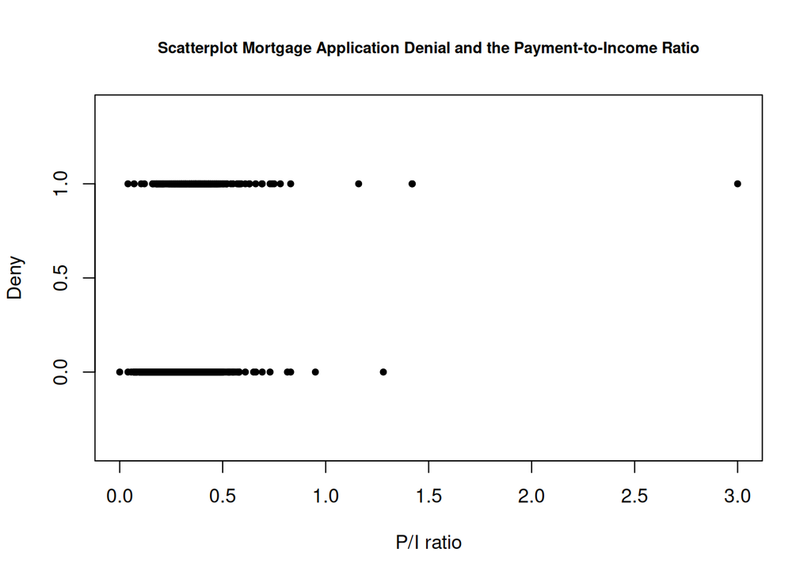

```r
# Scatter plot
plot(x = hmda.dat$pirat,
     y = hmda.dat$deny,
     main = "Scatterplot Mortgage Application Denial and the Payment-to-Income Ratio",
     xlab = "P/I ratio",
     ylab = "Deny",
     pch = 20,
     ylim = c(-0.4, 1.4),
     cex.main = 0.8)
```

- $deny$ is a binary variable.
- $12\%$ of all applications are denied.

*Add your Interpretation here!*

### Task b)

Estimate a linear probability model with $deny$ as dependent and $pirat$ as independent variable. Calculate the “effect” of an increase of the variable $pirat$ from $0.2$ to $0.3$ and from $0.6$ to $0.7$. Add the fitted regression line to the scatter plot from task a). Discuss the results.

Estimation

```r
# linear probability model 1
lin.mod.01 <- lm_ct_fun(deny ~ pirat, data = hmda.dat, hc.type="HC1")
lin.mod.01$ct
```

```r
# linear probability model 1
lin.mod.01 <- lm_ct_fun(deny ~ pirat, data = hmda.dat, hc.type="HC1")
lin.mod.01$ct
```

```
##
## t test of coefficients:
##
##              Estimate Std. Error t value  Pr(>|t|)
## (Intercept) -0.079910   0.031967 -2.4998   0.01249 *
## pirat        0.603535   0.098483  6.1283 1.036e-09 ***
## ---
## Signif. codes:  0 '***' 0.001 '**' 0.01 '*' 0.05 '.' 0.1 ' ' 1
```

Scatter Plot

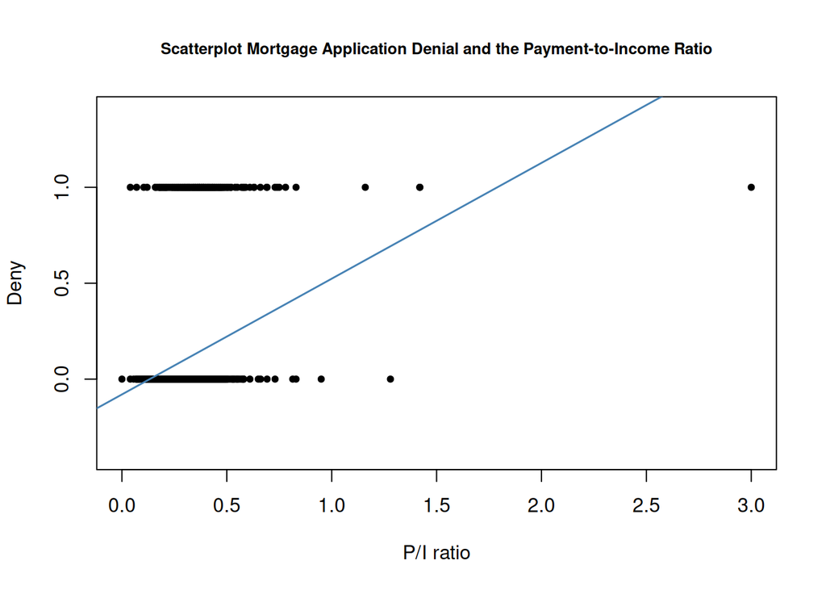

```r
# Scatter plot
plot(x = hmda.dat$pirat,
     y = hmda.dat$deny,
     main = "Scatterplot Mortgage Application Denial and the Payment-to-Income Ratio",
     xlab = "P/I ratio",
     ylab = "Deny",
     pch = 20,
     ylim = c(-0.4, 1.4),
     cex.main = 0.8)
# Fitted regression line
abline(lin.mod.01,
       lwd = 1.5,
       col = "steelblue")
```

Effects

Individual Predictions

$$\begin{align*}
\widehat{Pr}\left(deny=1|pirat=.2\right) = -.0799 + .6035\times.2 =
.0408
\end{align*}$$

$$\begin{align*}
\widehat{Pr}\left(deny=1|pirat=.3\right) = -.0799 + .6035\times.3 =
.1012
\end{align*}$$

*Add your results here!*

Effect

*Add your results here!*

Interpretation

- Increase in probability by $.0604$
- Increase in probability by $6.04$ percentage points
- Significant at $0.01$% level.
- Constant effect for all levels of $pirat$

*Add your interpretation here!*

### Task c)

Transform the variable $black$ into a binary variable ($1$ individual is African-American and $0$ otherwise) and include it as additional regressor. Calculate the “effect” of the variable $black$ for the fixed variable $pirat$ equals $0.3$. Discuss the results. Discuss the advantages and disadvantages of the linear probability model and a strategy to overcome the disadvantages.

Transform into binary variable

```r
# Original variable
str(hmda.dat$black)
# Transform variable
hmda.dat$black <- as.numeric(hmda.dat$black) - 1
str(hmda.dat$black)
```

```r
# Original variable
str(hmda.dat$black)
```

```
##  Factor w/ 2 levels "no","yes": 1 1 1 1 1 1 1 1 1 1 ...
```

```r
# Transform variable
hmda.dat$black <- as.numeric(hmda.dat$black) - 1
str(hmda.dat$black)
```

```
##  num [1:2380] 0 0 0 0 0 0 0 0 0 0 ...
```

Estimation

```r
# linear probability model 2
lin.mod.02 <- lm_ct_fun(deny ~ pirat + black, data = hmda.dat, hc.type="HC1")
lin.mod.02$ct
```

```r
# linear probability model 2
lin.mod.02 <- lm_ct_fun(deny ~ pirat + black, data = hmda.dat, hc.type="HC1")
lin.mod.02$ct
```

```
##
## t test of coefficients:
##
##              Estimate Std. Error t value  Pr(>|t|)
## (Intercept) -0.090514   0.028600 -3.1649  0.001571 **
## pirat        0.559195   0.088666  6.3067 3.387e-10 ***
## black        0.177428   0.024946  7.1124 1.502e-12 ***
## ---
## Signif. codes:  0 '***' 0.001 '**' 0.01 '*' 0.05 '.' 0.1 ' ' 1
```

Effects

Individual Predictions

$$\begin{align*}
\widehat{Pr}\left(deny=1|pirat=.3,black=0\right) = -.0905 +
.5592\times.3 = .0773
\end{align*}$$

$$\begin{align*}
\widehat{Pr}\left(deny=1|pirat=.3,black=1\right) = -.0905 +
.5592\times.3 + .1774 = .2547
\end{align*}$$

*Add your results here!*

Effect

$$\begin{align*}
&\phantom{=} \widehat{Pr}\left(deny=1|pirat=.3,black=1\right) -
\widehat{Pr}\left(deny=1|pirat=.3,black=0\right) \\
&= .2547 - .0773 \\
&= .1774 \\
&= \widehat{\beta}_{black}
\end{align*}$$

*Add your results here!*

Interpretation

- Increase in probability by $.1774$
- Increase in probability by $17.74$ percentage points
- Significant at $0.1$% level.

*Add your interpretation here!*

Discussion linear probability model

- Advantages: Easy to estimate and interpret
- Disadvantages: Functional form
  - Predicted probabilities can exceed 1 and fall below 0
  - Constant effect is potentially unrealistic

*Add your results here!*

### Task d)

Estimate a probit regression model with $deny$ as dependent and $pirat$ as independent variable and repeat the analysis of task b). Include the variable $black$ as additional variable and repeat the analysis of task c).

Specification

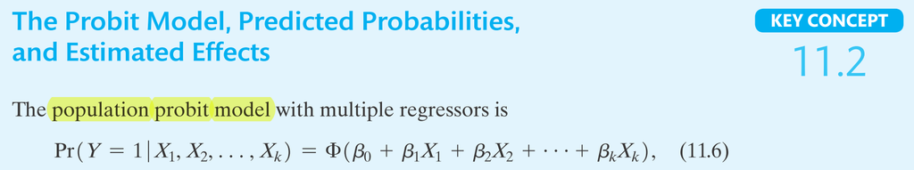

Source: Stock and Watson (2020) on p. 400

Estimation

```r
# probit model 1
prob.mod.01 <- glm_ct_fun(deny ~ pirat, family = binomial(link = "probit") , data = hmda.dat, hc.type="HC1")
prob.mod.01$ct
```

```r
# probit model 1
prob.mod.01 <- glm_ct_fun(deny ~ pirat, family = binomial(link = "probit") , data = hmda.dat, hc.type="HC1")
prob.mod.01$ct
```

```
##
## z test of coefficients:
##
##             Estimate Std. Error  z value  Pr(>|z|)
## (Intercept) -2.19415    0.18901 -11.6087 < 2.2e-16 ***
## pirat        2.96787    0.53698   5.5269 3.259e-08 ***
## ---
## Signif. codes:  0 '***' 0.001 '**' 0.01 '*' 0.05 '.' 0.1 ' ' 1
```

Different standard errors

- The standard errors for the probit model using the `glm()` function are different from the textbook.
- The reason is that the `glm()` function uses a different fitting algorithm than, e.g., the `probit` command in STATA.

Another function

```r
# Estimation
#install.packages("sampleSelection") # install package first
library("sampleSelection")
prob.mod.01.x <- probit(deny ~ pirat, data = hmda.dat)
# Robust inference
library("sandwich")
library("lmtest")
ct.prob.mod.01.x <- coeftest(prob.mod.01.x, vcov=vcovHC(prob.mod.01.x, type="HC0"))
ct.prob.mod.01.x
```

```r
# Estimation
#install.packages("sampleSelection") # install package first
library("sampleSelection")
prob.mod.01.x <- probit(deny ~ pirat, data = hmda.dat)
# Robust inference
library("sandwich")
library("lmtest")
ct.prob.mod.01.x <- coeftest(prob.mod.01.x, vcov=vcovHC(prob.mod.01.x, type="HC0"))
ct.prob.mod.01.x
```

```
##
## t test of coefficients:
##
##             Estimate Std. Error  t value  Pr(>|t|)
## (Intercept) -2.19416    0.16494 -13.3027 < 2.2e-16 ***
## pirat        2.96791    0.46522   6.3795 2.128e-10 ***
## ---
## Signif. codes:  0 '***' 0.001 '**' 0.01 '*' 0.05 '.' 0.1 ' ' 1
```

Scatterplot

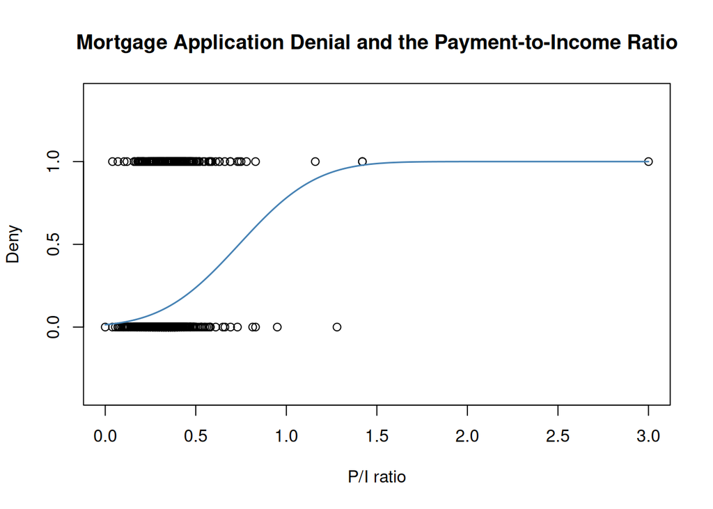

```r
# Scatterplot
plot(x = hmda.dat$pirat,
     y = hmda.dat$deny,
     main = "Mortgage Application Denial and the Payment-to-Income Ratio",
     xlab = "P/I ratio",
     ylab = "Deny",
     ylim = c(-0.4, 1.4))
# Fitted values
x <- seq(0, 3, 0.01)
y <- predict(prob.mod.01, list(pirat = x), type = "response")
# Fitted regression line
lines(x, y, lwd = 1.5, col = "steelblue")
```

Estimation

```r
# probit model 2
prob.mod.02 <- glm_ct_fun(deny ~ pirat + black, family = binomial(link = "probit") , data = hmda.dat, hc.type="HC1")
prob.mod.02$ct
```

```r
# probit model 2
prob.mod.02 <- glm_ct_fun(deny ~ pirat + black, family = binomial(link = "probit") , data = hmda.dat, hc.type="HC1")
prob.mod.02$ct
```

```
##
## z test of coefficients:
##
##              Estimate Std. Error  z value  Pr(>|z|)
## (Intercept) -2.258787   0.176608 -12.7898 < 2.2e-16 ***
## pirat        2.741779   0.497673   5.5092 3.605e-08 ***
## black        0.708155   0.083091   8.5227 < 2.2e-16 ***
## ---
## Signif. codes:  0 '***' 0.001 '**' 0.01 '*' 0.05 '.' 0.1 ' ' 1
```

Effects

Individual Predictions

$$\begin{align*}
\widehat{Pr}\left(deny=1|pirat=.3,black=0\right) &= \Phi\left(
-2.2588 + 2.742\times.3 \right) \\
&= \Phi\left( -1.4362 \right) \\
&= .0749
\end{align*}$$

$$\begin{align*}
\widehat{Pr}\left(deny=1|pirat=.3,black=1\right) &= \Phi\left(
-2.2588 + 2.742\times.3 + .7082 \right) \\
&= \Phi\left( -0.7280 \right) \\
&= .2327
\end{align*}$$

*Add your results here!*

Cumulative standard normal distribution function

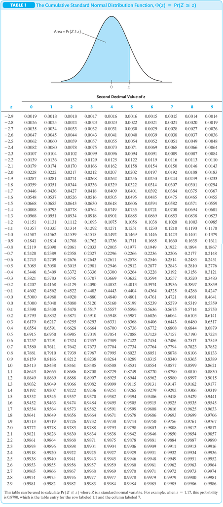

Source: Stock and Watson (2020) on p. 763-764

Effect

$$\begin{align*}
&\phantom{=} \widehat{Pr}(deny=1|pirat=.3,black=1) -
\widehat{Pr}(deny=1|pirat=.3,black=0) \\
&= .2327 - .0749 \\
&= .1578 \\
&\neq \widehat{\beta}_{black} \\
&\neq \Phi\left(\widehat{\beta}_{black}\right)
\end{align*}$$

Interpretation

- Increase in probability by $.1578$
- Increase in probability by $15.78$ percentage points
- Being black significantly increases the probability of denial.

*Add your results here!*

```r
# Individual predictions
ind.pred <- predict(prob.mod.02,
                    newdata = data.frame("pirat" = c(0.3, 0.3),
                                         "black" = c(0, 1)),
                    type = "response")
# Effect
diff(ind.pred)
```

```r
# Individual predictions
ind.pred <- predict(prob.mod.02,
                    newdata = data.frame("pirat" = c(0.3, 0.3),
                                         "black" = c(0, 1)),
                    type = "response")
# Effect
diff(ind.pred)
```

```
##         2
## 0.1578117
```

Discussion probit model

- Advantages: Functional form
  - Predicted probabilities cannot exceed 1 and cannot fall below 0
  - Non-constant effect is potentially more realistic
- Disadvantages:
  - Estimated coefficients can only be interpreted qualitatively
  - For the calculation of the “effects” the table of the CDF of the standard normal distribution has to be used.

*Add your results here!*

### Task e)

Repeat task d) using a logit model. Discuss the results.

Specification

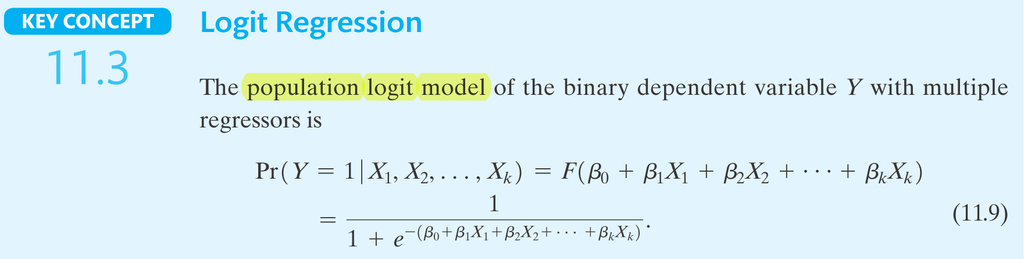

Source: Stock and Watson (2020) on p. 402

Estimation

```r
# logit model 1
log.mod.01 <- glm_ct_fun(deny ~ pirat, family = binomial(link = "logit") , data = hmda.dat, hc.type="HC1")
log.mod.01$ct
```

```r
# logit model 1
log.mod.01 <- glm_ct_fun(deny ~ pirat, family = binomial(link = "logit") , data = hmda.dat, hc.type="HC1")
log.mod.01$ct
```

```
##
## z test of coefficients:
##
##             Estimate Std. Error  z value  Pr(>|z|)
## (Intercept) -4.02843    0.35898 -11.2218 < 2.2e-16 ***
## pirat        5.88450    1.00015   5.8836 4.014e-09 ***
## ---
## Signif. codes:  0 '***' 0.001 '**' 0.01 '*' 0.05 '.' 0.1 ' ' 1
```

Scatterplot

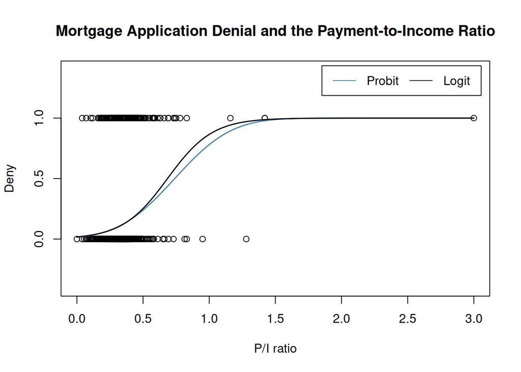

```r
# Scatterplot
plot(x = hmda.dat$pirat,
     y = hmda.dat$deny,
     main = "Mortgage Application Denial and the Payment-to-Income Ratio",
     xlab = "P/I ratio",
     ylab = "Deny",
     ylim = c(-0.4, 1.4))
# Fitted values
x <- seq(0, 3, 0.01)
y.prob <- predict(prob.mod.01, list(pirat = x), type = "response")
y.log  <- predict(log.mod.01, list(pirat = x), type = "response")
# Fitted regression line
lines(x, y.prob, lwd = 1.5, col = "steelblue")
lines(x, y.log, lwd = 1.5, col = "black")
# Legend
legend("topright",inset=.02,
       horiz = TRUE,
       legend = c("Probit", "Logit"),
       col = c("steelblue", "black"),
       lty = c(1, 1))
```

Estimation

```r
# logit model 2
log.mod.02 <- glm_ct_fun(deny ~ pirat + black, family = binomial(link = "logit") , data = hmda.dat, hc.type="HC1")
log.mod.02$ct
```

```r
# logit model 2
log.mod.02 <- glm_ct_fun(deny ~ pirat + black, family = binomial(link = "logit") , data = hmda.dat, hc.type="HC1")
log.mod.02$ct
```

```
##
## z test of coefficients:
##
##             Estimate Std. Error  z value  Pr(>|z|)
## (Intercept) -4.12556    0.34597 -11.9245 < 2.2e-16 ***
## pirat        5.37036    0.96376   5.5723 2.514e-08 ***
## black        1.27278    0.14616   8.7081 < 2.2e-16 ***
## ---
## Signif. codes:  0 '***' 0.001 '**' 0.01 '*' 0.05 '.' 0.1 ' ' 1
```

Effects

Individual Predictions

$$\begin{align*}
\widehat{Pr}\left(deny=1|pirat=.3,black=0\right) &= F\left(-4.1256 +
5.3704\times.3\right) \\
&= \frac{1}{1+e^{-\left(-4.1256 + 5.3704\times.3\right)}} \\
&= .0748
\end{align*}$$

$$\begin{align*}
\widehat{Pr}\left(deny=1|pirat=.3,black=1\right) &= F\left(-4.1256 +
5.3704\times.3 + 1.2728\right) \\
&= \frac{1}{1+e^{-\left(-4.1256 + 5.3704\times.3 + 1.2728\right)}}
\\
&= .2241
\end{align*}$$

*Add your results here!*

Effect

$$\begin{align*}
&\phantom{=} \widehat{Pr}(deny=1|pirat=.3,black=1) -
\widehat{Pr}(deny=1|pirat=.3,black=0) \\
&= .2241 - .0748 \\
&= .1493 \\
&\neq \widehat{\beta}_{black} \\
&\neq F\left(\widehat{\beta}_{black}\right)
\end{align*}$$

*Add your results here!*

Interpretation

- Increase in probability by $.1493$
- Increase in probability by $14.93$ percentage points
- Being black significantly increases the probability of denial.

*Add your results here!*

```r
# Individual predictions
ind.pred <- predict(log.mod.02,
                    newdata = data.frame("pirat" = c(0.3, 0.3),
                                         "black" = c(0, 1)),
                    type = "response")
# Effect
diff(ind.pred)
```

```r
# Individual predictions
ind.pred <- predict(log.mod.02,
                    newdata = data.frame("pirat" = c(0.3, 0.3),
                                         "black" = c(0, 1)),
                    type = "response")
# Effect
diff(ind.pred)
```

```
##         2
## 0.1492945
```

Discussion logit model

Similar to the probit model!

*Add your results here!*

### Task f)

Compare and contrast the results about the estimated “effect” of a change an increase of $pirat$ from $0.2$ to $0.3$ and $0.6$ to $0.7$ for the three estimated models as computed in b), d) and e).

```r
#...............................
# Linear probability model No 01
## 0.2 -> 0.3
pre.01.lin.mod.01 <- predict(lin.mod.01, newdata = data.frame("pirat" = c(0.2, 0.3)), type = "response")
eff.01.lin.mod.01 <- diff(pre.01.lin.mod.01)
eff.01.lin.mod.01
## 0.6 -> 0.7
pre.02.lin.mod.01 <- predict(lin.mod.01, newdata = data.frame("pirat" = c(0.6, 0.7)), type = "response")
eff.02.lin.mod.01 <- diff(pre.02.lin.mod.01)
eff.02.lin.mod.01
#...............................
# Probit model No 01
## 0.2 -> 0.3
pre.01.prob.mod.01 <- predict(prob.mod.01, newdata = data.frame("pirat" = c(0.2, 0.3)), type = "response")
eff.01.prob.mod.01 <- diff(pre.01.prob.mod.01)
eff.01.prob.mod.01
## 0.6 -> 0.7
pre.02.prob.mod.01 <- predict(prob.mod.01, newdata = data.frame("pirat" = c(0.6, 0.7)), type = "response")
eff.02.prob.mod.01 <- diff(pre.02.prob.mod.01)
eff.02.prob.mod.01
#...............................
# Logit model No 01
## 0.2 -> 0.3
pre.01.log.mod.01 <- predict(log.mod.01, newdata = data.frame("pirat" = c(0.2, 0.3)), type = "response")
eff.01.log.mod.01 <- diff(pre.01.log.mod.01)
eff.01.log.mod.01
## 0.6 -> 0.7
pre.02.log.mod.01 <- predict(log.mod.01, newdata = data.frame("pirat" = c(0.6, 0.7)), type = "response")
eff.02.log.mod.01 <- diff(pre.02.log.mod.01)
eff.02.log.mod.01
```

```r
#...............................
# Linear probability model No 01
## 0.2 -> 0.3
pre.01.lin.mod.01 <- predict(lin.mod.01, newdata = data.frame("pirat" = c(0.2, 0.3)), type = "response")
eff.01.lin.mod.01 <- diff(pre.01.lin.mod.01)
eff.01.lin.mod.01
```

```
##          2
## 0.06035349
```

```r
## 0.6 -> 0.7
pre.02.lin.mod.01 <- predict(lin.mod.01, newdata = data.frame("pirat" = c(0.6, 0.7)), type = "response")
eff.02.lin.mod.01 <- diff(pre.02.lin.mod.01)
eff.02.lin.mod.01
```

```
##          2
## 0.06035349
```

```r
#...............................
# Probit model No 01
## 0.2 -> 0.3
pre.01.prob.mod.01 <- predict(prob.mod.01, newdata = data.frame("pirat" = c(0.2, 0.3)), type = "response")
eff.01.prob.mod.01 <- diff(pre.01.prob.mod.01)
eff.01.prob.mod.01
```

```
##          2
## 0.04141753
```

```r
## 0.6 -> 0.7
pre.02.prob.mod.01 <- predict(prob.mod.01, newdata = data.frame("pirat" = c(0.6, 0.7)), type = "response")
eff.02.prob.mod.01 <- diff(pre.02.prob.mod.01)
eff.02.prob.mod.01
```

```
##         2
## 0.1139257
```

```r
#...............................
# Logit model No 01
## 0.2 -> 0.3
pre.01.log.mod.01 <- predict(log.mod.01, newdata = data.frame("pirat" = c(0.2, 0.3)), type = "response")
eff.01.log.mod.01 <- diff(pre.01.log.mod.01)
eff.01.log.mod.01
```

```
##          2
## 0.03962478
```

```r
## 0.6 -> 0.7
pre.02.log.mod.01 <- predict(log.mod.01, newdata = data.frame("pirat" = c(0.6, 0.7)), type = "response")
eff.02.log.mod.01 <- diff(pre.02.log.mod.01)
eff.02.log.mod.01
```

```
##         2
## 0.1445901
```

Overview effects

|  | Linear | Probit | Logit |
| --- | --- | --- | --- |
| 0.2 - 0.3 | 0.060 | 0.041 | 0.040 |
| 0.6 - 0.7 | 0.060 | 0.114 | 0.145 |

Discussion effects

- Probit & Logit vs. linear:
  - Effects are quite different
  - Effects are constant for the linear probability model but different for the probit and logit model
- Probit vs. Logit: Effects are quite similar

*Add your results here!*

### Task g)

Discuss potential measures of fit for the logit and probit model and calculate these measure for the probit and logit model in task d) and e).

Measures of fit

$\underline{R}^2$

- Continuous variables: $R^2=1$ implies a perfect fit
- Binary dependent and continuous independent variable: $R^2=1$ is not possible!

Pseudo / MC Fadden $\underline{R}^2$

$$\begin{align*}
pseudo-R^2=1-\frac{ln\left(f_{full}^{max}\right)}{ln\left(f_{null}^{max}\right)}
\end{align*}$$

- $f_{full}^{max} \in \left[0,1\right]$ as the maximized likelihood of the full model.
- $f_{null}^{max} \in \left[0,1\right]$ as the maximized likelihood of the model with only a constant.

Number of cases “correctly predicted”

- $Y_i$ is correctly if $y_i=1$ and $\widehat{Pr}(Y_i=1|X_i)>0.5$
- $Y_i$ is correctly if $y_i=0$ and $\widehat{Pr}(Y_i=1|X_i)\leq 0.5$

Pseudo / MC Fadden $\underline{R}^2$

```r
# Pseudo / Mc Fadden R2
prob.mod.00 <- glm(deny ~ 1, family = binomial(link = "probit"), data = hmda.dat) # Estimate null model
pr2.prob.mod.02 <- 1-logLik(prob.mod.02)[1]/logLik(prob.mod.00)[1]
pr2.prob.mod.02
```

```r
# Pseudo / Mc Fadden R2
prob.mod.00 <- glm(deny ~ 1, family = binomial(link = "probit"), data = hmda.dat) # Estimate null model
pr2.prob.mod.02 <- 1-logLik(prob.mod.02)[1]/logLik(prob.mod.00)[1]
pr2.prob.mod.02
```

```
## [1] 0.08594259
```

Percentage of correctly predicted

```r
# Data and model
y     <- hmda.dat$deny
model <- prob.mod.02
# Percentage of correctly predicted
y.pre   <- ifelse(model$fitted.values>.5,1,0)
cor.pre <- y.pre==y
pct.cor.pre <- 100*(sum(cor.pre)/length(y))
pct.cor.pre
```

```r
# Data and model
y     <- hmda.dat$deny
model <- prob.mod.02
# Percentage of correctly predicted
y.pre   <- ifelse(model$fitted.values>.5,1,0)
cor.pre <- y.pre==y
pct.cor.pre <- 100*(sum(cor.pre)/length(y))
pct.cor.pre
```

```
## [1] 88.19328
```

```r
# Table for true and predicted
table(true = hmda.dat$deny, pred = round(fitted(prob.mod.02)))
```

```
##     pred
## true    0    1
##    0 2089    6
##    1  275   10
```

Results for logit model

```r
# Pseudo / Mc Fadden R2
log.mod.00 <- glm(deny ~ 1, family = binomial(link = "logit"), data = hmda.dat) # Estimate null model
pr2.log.mod.02 <- 1-logLik(log.mod.02)[1]/logLik(log.mod.00)[1]
pr2.log.mod.02
```

```
## [1] 0.08759475
```

```r
# Data and model
y     <- hmda.dat$deny
model <- log.mod.02
# Percentage of correctly predicted
y.pre   <- ifelse(model$fitted.values>.5,1,0)
cor.pre <- y.pre==y
pct.cor.pre <- 100*(sum(cor.pre)/length(y))
pct.cor.pre
```

```
## [1] 88.27731
```

Interpretation

- In general the fit of the probit and logit specification is very similar.
- According to the pseudo $R^2$ and PCP the logit specification results in a slightly better fit.

*Add your interpretation here!*

Back To *Start*